# PYTHON 3

#### 2.5. Поверхности

Все поверхности параметрические: $x=x(u,v)$, $y=y(u,v)$, $z=z(u,v)$. Если мы хотим построить явную поверхность $z=z(x,y)$, то удобно создать массивы $x=u$ и $y=v$ функцией `meshgrid`.

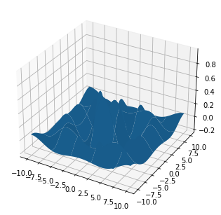

```python
X = 10
N = 50
u = np.linspace(-X, X, N)
x, y = np.meshgrid(u, u)
r = np.sqrt(x ** 2 + y ** 2)
z = np.sin(r) / r

fig = plt.figure()
ax = Axes3D(fig)
ax.plot_surface(x, y, z, rstride=10, cstride=10)
plt.show()
```

Есть много встроенных способов раскраски поверхностей. Так, в методе `gnuplot` цвет зависит от высоты $z$.

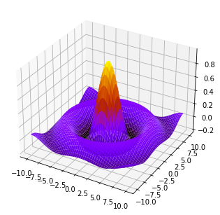

```python
fig = plt.figure()
ax = Axes3D(fig)
ax.plot_surface(x, y, z, rstride=1, cstride=1, cmap='gnuplot')
plt.show()
```

Построим бублик — параметрическую поверхность с параметрами $\theta$, $\varphi$.

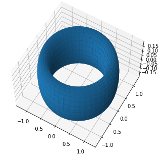

```python
t = np.linspace(0, 2 * np.pi, 50)
th, ph = np.meshgrid(t, t)
r = 0.2
x, y, z = (1 + r * np.cos(ph)) * np.cos(th), (1 + r * np.cos(ph)) * np.sin(th), r * np.sin(ph)

fig = plt.figure()
ax = Axes3D(fig)
ax.elev = 60
ax.plot_surface(x, y, z, rstride=2, cstride=1)
plt.show()
```

### Цветовая палитра

При построении отдельных кривых, можно задавать цвета следующим образом:

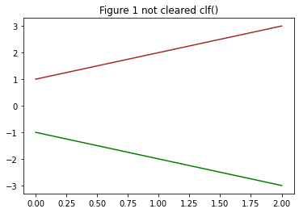

```python
f1 = plt.figure()
plt.plot([1, 2, 3], 'brown', [-1,-2,-3], 'green')
plt.title("Figure 1 not cleared clf()")
plt.show()
```

Сменить палитру цветов для 3-хмерного графика можно следующим образом:

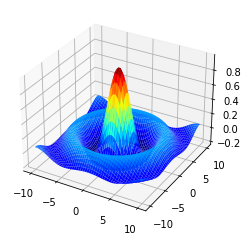

```python
X = 10
N = 50
u = np.linspace(-X, X, N)
x, y = np.meshgrid(u, u)
r = np.sqrt(x ** 2 + y ** 2)
z = np.sin(r) / r

fig = plt.figure()
ax = fig.add_subplot(projection='3d')
ax.plot_surface(x, y, z, cmap='jet')
plt.show()
```

Кроме этого есть палитры `hot`, `cool` и многое другое. С ними можете поэкспериментировать сами. Также можете использовать один цвет, тогда, например, вместо cmap='jet' пишите color='green'.

### Plt.fill()

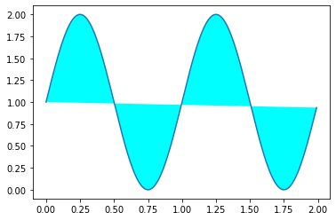

```python
x = np.arange(0.0, 2.0, 0.01)
y = 1 + np.sin(2 * np.pi * x)
plt.plot(x, y)

plt.fill(x, y, "cyan")
plt.show()
```

### Рисование фигур на графиках

Пакет matplotlib позволяет рисовать произвольные фигуры прямо в координатных осях. Это очень удобно, когда нужно добавить нестандартную графическую информацию к отображаемому графику. Давайте посмотрим как это делается.

Для начала рассмотрим создание ломаной линии с помощью класса Line2D:

```python
from matplotlib.lines import Line2D
```

Объект ломаной создается путем передачи списка координат по x и y конструктору этого класса:

```python
l1 = Line2D([1, 2, 3], [1, 2, 3])
```

Затем, вызвать метод add_line() и прописать граничные значения, чтобы линия была видна в поле рисования графика:

```
[(0.0, 4.0), (0.0, 4.0)]
```

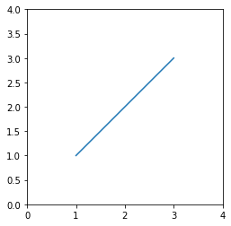

```python
fig, ax = plt.subplots(subplot_kw=dict(aspect='equal'))
ax.add_line(l1)
ax.set(xlim=[0, 4], ylim=[0, 4])
```

Классы других стандартных геометрических фигур находятся в модуле:

```python
from matplotlib.patches import *
```

Полный список классов можно посмотреть в официальной документации:

https://matplotlib.org/stable/api/patches_api.html

Например, можно нарисовать эллипс с помощью класса `Ellipse`:

```python
el = Ellipse((0, 0), 10, 20, facecolor='r', alpha=0.5)
```

```
[(-20.0, 20.0), (-20.0, 20.0)]
```

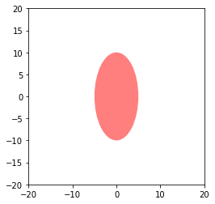

```python
fig, ax = plt.subplots(subplot_kw=dict(aspect='equal'))
ax.add_artist(el)
ax.set(xlim=[-20, 20], ylim=[-20, 20])
```

Построим тот же эллипс, но добавим к нему стрелку:

```
[(-20.0, 20.0), (-20.0, 20.0)]
```

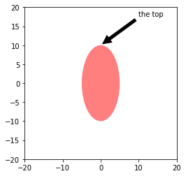

```python
el = Ellipse((0, 0), 10, 20, facecolor='r', alpha=0.5)

fig, ax = plt.subplots(subplot_kw=dict(aspect='equal'))
ax.add_artist(el)
el.set_clip_box(ax.bbox)
ax.annotate('the top',
            xy=(np.pi/2., 10.),      # theta, radius
            xytext=(np.pi/3, 20.),   # theta, radius
            xycoords='polar',
            textcoords='polar',
            arrowprops=dict(facecolor='black', shrink=0.05),
            horizontalalignment='left',
            verticalalignment='bottom',
            clip_on=True)  # clip to the axes bounding box

ax.set(xlim=[-20, 20], ylim=[-20, 20])
```

Аналогично можно использовать любой другой класс модуля matplotlib.patches.